# Camera

# Camera allows you to see in 3D space

The `Camera` node allows you to see and manipulate the view in 3D environments. You can attach them to any other moving node to follow it.

In this guide, you’ll learn to:

- Set up a `Camera` node and use its key methods and signals.
- Create third and first-person player cameras.
- Adjust the field of view when the player sprints.
- Change the player’s view to focus on objects in a scene.
- Shake the view when the player takes damage.

Contents:

- Setting up a Camera node
- Camera’s key properties and methods
  - Changing the Camera’s position
  - Controlling the field of view
  - Controlling the projection-type
  - Offsetting the Camera
  - Switching to different cameras
  - Detecting where the player clicked
- How to use a camera in practice
  - Making a first-person camera
  - Making a third-person camera
  - Making the player feel faster when they sprint
  - Smoothly moving the camera between targets
  - Screen shake in 3D
- Troubleshooting
  - Objects get clipped near the camera or in the distance
  - My Camera doesn’t rotate the way I expect
- Your questions
  - How can I find if an object is in front of the camera?
  - How can I mark the position of a 3D object on the screen?
  - What are Cull Masks?

## Setting up a Camera node

Every 3D scene requires a `Camera` node to render anything. Once you add a `Camera` to your scene and run the game, Godot renders the world and displays its contents on the screen.

You can preview what the `Camera` sees in the editor. To do so:

1. Select the `Camera` node.
2. Click the *Preview* checkmark in the top left of the viewport.

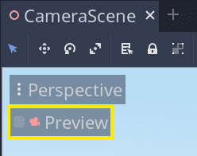

To manipulate the `Camera` with the preview active, you can split the viewport. Press `Ctrl`+`2` to split the viewport vertically or `Ctrl`+`Alt`+`2` to split it horizontally.

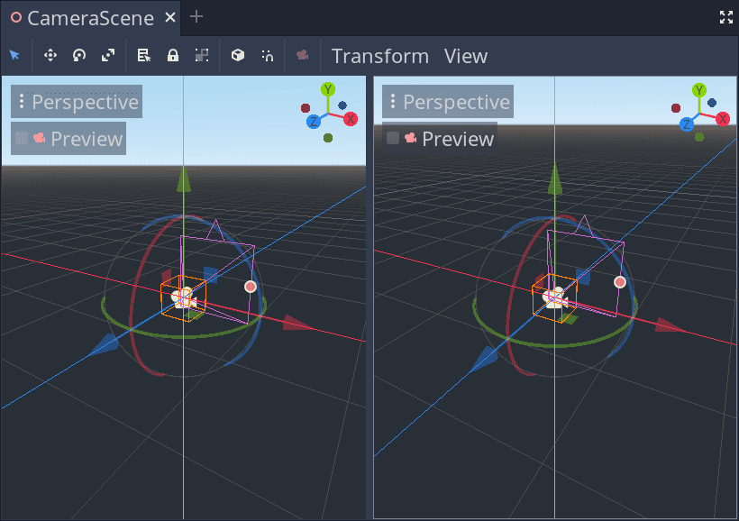

You can find more view layout options in the *View* menu in the toolbar.

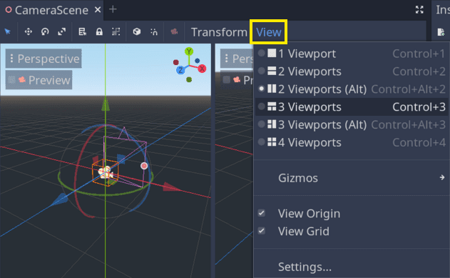

The preview updates as you move and rotate the `Camera` using the *Move* and *Rotate* gizmos.

You can also align the `Camera` node with your view in a given viewport. Move your view as desired, then, with the `Camera` selected, click on *Perspective -> Align Transform With View* in the top-left of the viewport or press `Ctrl`+`Alt`+`M`.

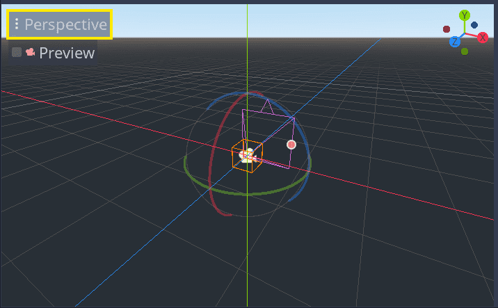

This feature works with any 3D node.

A scene can have any amount of `Camera` nodes, but only one can be active at a time.

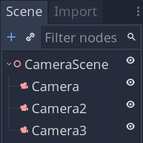

If you have more than one `Camera` in the scene, you must tick the *Current* property on one of them to make it active. More precisely, the last `Camera` node you set to *Current* becomes the active one.

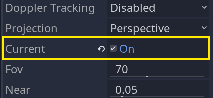

## Camera’s key properties and methods

In 3D, cameras are even more important and powerful than in 2D. With them, you can:

- Take control of the camera’s field of view with the *Fov* property.
- Create isometric and perspective views with the *Projection* property.
- Offset the camera view from the node’s position with *H Offset* and *V Offset*. This is ideal for camera shake.
- Switch to different cameras using the `make_current()` and `clear_current()` methods.
- Detect where the player clicked in the world with the `project_` methods.

### Changing the Camera’s position

The most common way to move a camera is to make it a child of a *PhysicsBody*, like `RigidBody` or `KinematicBody`, to synchronize camera movement with the body movement.

You can also use a `RemoteTransform` to move a camera elsewhere in the scene without inheriting the player’s rotation. Read the RemoteTransform guide for more information.

You can also interpolate its `Transform` as a way to escape gimbal lock. See the subheading in the gimbal-lock-and-quaternions guide for more information.

### Controlling the field of view

Field of view, or the *Fov* property, is an angle representing the camera’s cone of vision.

The higher the field of view, the more the player can see around them. As you increase the value, you exaggerate the game’s perspective effects. Too high of a field of view can cause the world to appear distorted.

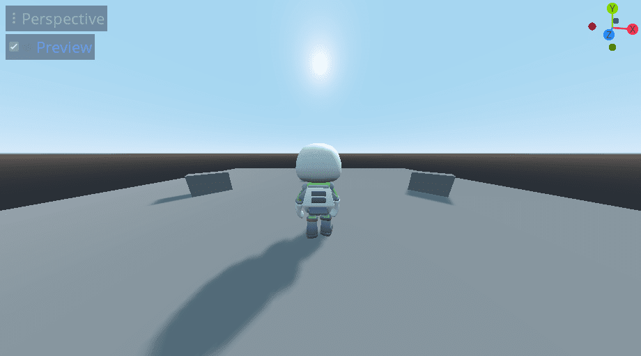

When you increase the camera’s *Fov* during player movement, their motion appears to be faster, as more of the world runs past the screen edges. Lowering the *Fov* during movement makes their movement appear slower, as less of the world appears on screen.

You may want to tune the field of view to fit your target platform. For example, a 3D game played on the TV often has a lower FOV to compensate for the distance between the player and the screen. A PC game often has a higher FOV since the player is much closer to the screen.

When in doubt, you can give players the option to set their preferred field of view.

### Controlling the projection-type

3D cameras offer two projection modes:

1. Orthographic mode, all lines in the game world are parallel, flattening the view. This view works well in 2.5D games when you mix 2D and 3D graphics.

[figure not shown]

   Game: *Monument Valley 2*, a 3D game using an orthographic projection.
2. In perspective mode, distant objects appear smaller than close ones. This is the default mode.

[figure not shown]

You can change the projection using the *Projection* property in the *Inspector*.

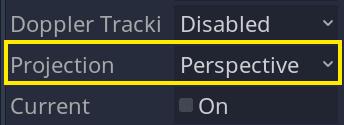

### Offsetting the Camera

Besides adjusting the camera’s position, you can make fine adjustments on top of the camera’s current position using the offset properties.

The *H Offset* and *V Offset* properties adjust the view of the `Camera`.

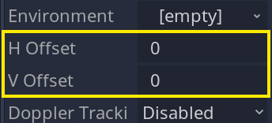

### Switching to different cameras

In 3D, the main viewport renders the game through whichever camera has the *Current* property set.

To make a camera the active one, you can check its *Current* property in the *Inspector*.

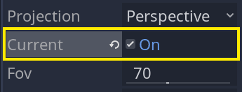

You can set another camera node to *Current* or call its `make_current()` method to change the active camera for a viewport.

### Detecting where the player clicked

In some games, the player needs to interact with 3D objects in the game world using their mouse or touchscreen as a 2D input.

However, these two methods only calculate points in space. You can use the `PhysicsDirectSpaceState` singleton to convert these points in space into a ray cast.

```
func _cast_ray_from_mouse() -> Dictionary:
    var mouse_position := get_viewport().get_mouse_position()
    # Project the 2D mouse position onto the camera.
    var from: Vector3 = project_ray_origin(mouse_position)
    # Project the 2D mouse position into the world from the camera.
    var to: Vector3 = from + project_ray_normal(mouse_position) * 1000
    # Ask the physics engine to do a raycast and return the result.
    return get_world().direct_space_state.intersect_ray(from, to, [self])
```

The function above returns an empty dictionary if the calculated ray does not intersect with anything. If the ray touches something, the dictionary gives you the position of the collision, the collider it hit, the collision normal, and other information if needed.

```
var result := _cast_ray_from_mouse()
if not result.empty():
    var collision_point: Vector2 = result.position
    var collision_normal: Vector2 = result.normal
    var collider: PhysicsBody2D = result.collider
```

You can find all the details in Godot’s [PhysicsDirectSpaceState documentation](https://docs.godotengine.org/en/stable/classes/class_physicsdirectspacestate.html#class-physicsdirectspacestate-method-intersect-ray).

## How to use a camera in practice

### Making a first-person camera

For 3D first-person shooters and role-playing games, a first-person `Camera` is essential.

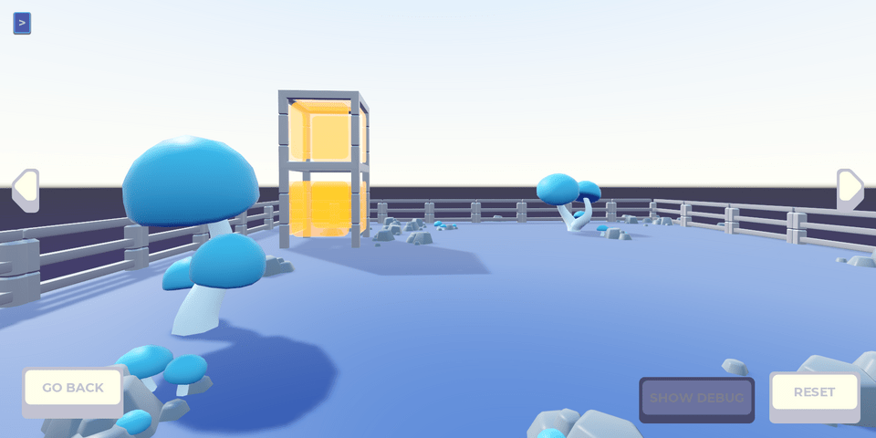

The core of a first-person player character is a `KinematicBody` with collision for movement and the `Camera`. You can use a `RayCast` for player interactions with the world.

[figure not shown]

We save the yaw or horizontal rotation and tilt or vertical rotation to two separate variables to apply those changes to the character one at a time for their axis of rotation.

```
var _yaw_input := 0.0
var _tilt_input := 0.0

func _input(event: InputEvent) -> void:
    if event is InputEventMouseMotion and Input.get_mouse_mode() == Input.MOUSE_MODE_CAPTURED:
        _yaw_input = -event.relative.x * mouse_sensitivity
        _tilt_input = -event.relative.y * mouse_sensitivity
```

We also need variables for the rotation rate and limits to how far the player can look up and down.

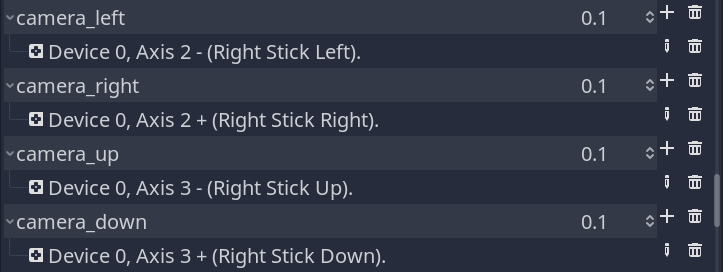

We apply our yaw first with the `rotate_y()` function, and then we apply our tilt on a separate pivot. Keeping our rotations separated avoids any confusion about the axis of rotation.

We use the `rotate_x()` function on the tilt pivot. Then we clamp our rotation to be within the boundaries defined by the upper and lower limits we defined earlier.

```
export var rotation_speed := 1.0
export var tilt_speed := 1.0

export(float, -90, 0.0) var tilt_upper_limit := -60.0
export(float, 0.0, 90.0) var tilt_lower_limit := 60.0

onready var _tilt_pivot: Spatial = $TiltPivot

func _physics_process(delta: float) -> void:
    _yaw_input += Input.get_action_strength("camera_left") - Input.get_action_strength("camera_right")
    _tilt_input += Input.get_action_strength("camera_up") - Input.get_action_strength("camera_down")

    rotate_y(_yaw_input * rotation_speed * delta)
    _tilt_pivot.rotate_x(_tilt_input * tilt_speed * delta)
    _tilt_pivot.rotation_degrees.x = clamp(
        _tilt_pivot.rotation_degrees.x,
        tilt_upper_limit,
        tilt_lower_limit)
```

After applying all rotations, we can reset the yaw and tilt variables to prevent re-applying the rotation on the next frame.

```
    # zero out input before next frame
    _yaw_input = 0.0
    _tilt_input = 0.0
```

### Making a third-person camera

Creating a third-person `Camera` is more complex than a first-person `Camera` in many ways: You need to avoid objects getting between the player and the `Camera` and clipping through world objects.

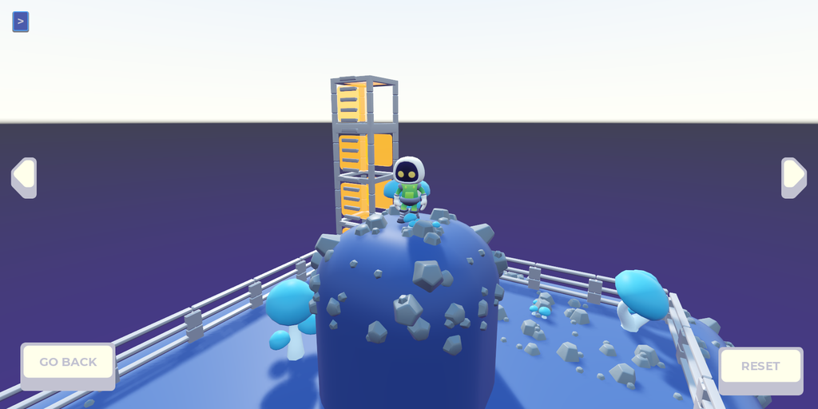

`ClippedCamera` and `SpringArm` are two powerful nodes that allow the camera to move closer to the player whenever other objects get in the way.

In our scene, we have a `Spatial` node attached to our player, a pivot around which the `Camera` rotates with an `AnimationPlayer`.

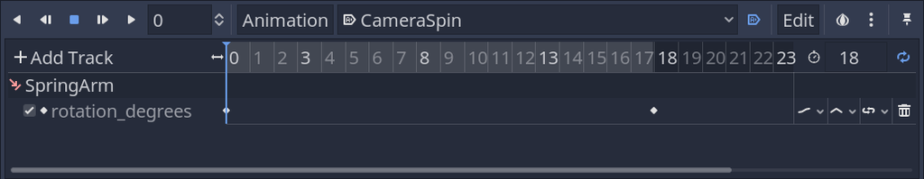

This pivot has a `SpringArm` as a child. The `SpringArm` casts a ray along its Z-axis.

If the `SpringArm` collides with anything, it moves the `Camera` inwards to avoid the collision, with a space given by the margin property.

You can customize the `CollisionShape` used for the casting check. In our case, we use a `CapsuleShape` to lightly smooth motion around hard edges.

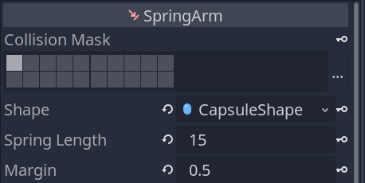

You can define two properties on a `SpringArm`:

1. *Spring Length*: how far the child can move to accommodate for collisions.
2. *Margin*: how much space to put between a collision point and the `Camera`.

[figure not shown]

### Making the player feel faster when they sprint

In some FPS games, the `Camera` view expands when sprinting to make the player’s movement feel faster. You can see this effect in games like *Minecraft* and *Overwatch*.

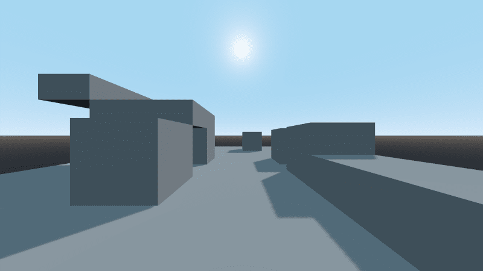

To replicate this effect, we can animate the field of view of the player’s `Camera`.

When the player presses the sprint key and moves, we can set a target, speed, and field of view. Then use the `lerp()` function to animate those properties in the `_physics_process()` function.

```
extends FPSPlayer

const MIN_RUN_VELOCITY := 1.0

var target_speed
var target_fov

export var sprint_speed := 10.0
export var sprint_field_of_view := 90.0

onready var original_speed := move_speed
onready var _camera: Camera = $TiltPivot/Camera
onready var default_field_of_view := _camera.fov


func _physics_process(delta: float) -> void:
    if Input.is_action_pressed("dash") and _velocity.length_squared() > MIN_RUN_VELOCITY:
        target_speed = sprint_speed
        target_fov = sprint_field_of_view
    else:
        target_speed = original_speed
        target_fov = default_field_of_view
    move_speed = lerp(move_speed, target_speed, delta * acceleration)
    _camera.fov = lerp(_camera.fov, target_fov, delta * acceleration)
```

### Smoothly moving the camera between targets

In 3D platform and action games, the `Camera` often needs to change position and angle to help the player navigate the world better, especially in games without direct control of the `Camera`, like the *God of War* games.

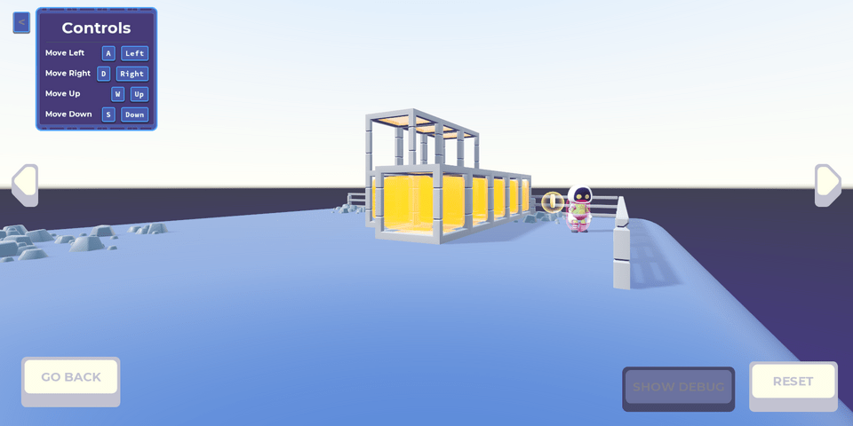

In this demo, we use areas where the `Camera` detaches from the player and moves to a fixed position to give a clearer view of the level.

To achieve this, we create an `Area` node with a predefined position. We have a `Position3D` node as a child to define the `Camera`’s anchor in the game world.

The area detects when the player character enters it and asks the `Camera` to move to the predefined position. When the character leaves the `Area`, we return the `Camera` to the player.

```
extends Area

onready var _position: Position3D = $Position3D


func _ready() -> void:
    connect("body_entered", self, "_on_Area_body_entered")
    connect("body_exited", self, "_on_Area_body_exited")


func _on_Area_body_entered(body: PhysicsBody) -> void:
    if body.has_method("change_camera_focus"):
        body.change_camera_focus(_position.global_transform)


func _on_Area_body_exited(body: PhysicsBody) -> void:
    if body.has_method("reset_camera_focus"):
        body.reset_camera_focus()
```

To detach the `Camera` from the character, we make it top-level. A top-level object moves independently from its parent and only works with global transforms. We can set this property with `set_as_toplevel(true)` in code on any `Spatial` node.

This property allows us to check the current state of the `Camera` and to move it based on its attachment to the player.

In `_physics_process()`, we give the `Camera` a different target transform depending on its state. If the `Camera` is top-level, it isn’t following the player, so we move it to the target we got entering the area.

Otherwise, we follow the player.

```
func _physics_process(delta: float) -> void:
    var camera_target: Transform = (
        target_transform
        if _camera_collision.is_set_as_toplevel()
        else _camera_parent.global_transform
    )
    _camera_collision.global_transform = interpolate_rotation(
        _camera_collision.global_transform, camera_target, 2.0 * delta
    )
    var camera_direction = _camera_collision.global_transform.origin.direction_to(
        camera_target.origin
    )
    global_transform.origin = _player.global_transform.origin + _camera_offset
    if _camera_collision.global_transform.origin.distance_to(camera_target.origin) > 0.4:
        _camera_collision.move_and_slide(camera_speed * camera_direction, Vector3.UP)


## Smoothly interpolates between two transforms' rotations using quaternions.
func interpolate_rotation(from: Transform, to: Transform, weight: float) -> Transform:
    # Using quaternions makes interpolation smoother and prevents Gimbal lock.
    var start_rotation := from.basis.get_rotation_quat()
    var target_rotation := to.basis.get_rotation_quat()
    return Transform(start_rotation.slerp(target_rotation, weight), from.origin)
```

### Screen shake in 3D

There’s nothing like screen shake to add appealing effects to a game. You can shake the view whenever the character takes a hit or when an explosion happens nearby. You can even simulate an ongoing earthquake.

Shaking the screen in 3D is similar to how we do it for a 2D camera, as seen in Camera2D. We can use a noise resource to randomize the *H Offset* and *V Offset* properties to shake the screen’s contents.

In this example, we attached a camera to our player node.

The shake logic happens in a script attached to the `Camera`. We define two properties to control the shake’s maximum amplitude and current intensity between `0` and `1`.

```
# The maximum offset applied to the camera in units.
export var max_amplitude := 0.3

# We turn processing on and off through this property's setter function.
var shake_intensity := 0.0 setget set_shake_intensity

# We made our noise generator in the editor and saved it as a text resource
# file. This allows us to edit it in the Inspector while the game runs,
# with live reloading.
var _noise := preload("3d_camera_noise.tres")



# We randomize the noise generator's seed to get a unique shake every time we
# play.
func _init() -> void:
    _noise.seed = randi()
```

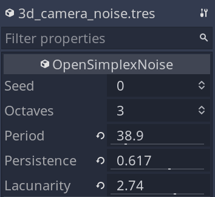

Here’s how it looks in texture-form:

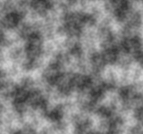

Using noise over a random number generator has many benefits. Properties can control the rate of change of values, and you can slow down the rate of screen shake easier, say if you have some slow-motion gameplay.

Changing the `shake_intensity` goes through a setter that toggles processing on and off.

```
func set_shake_intensity(intensity: float) -> void:
    shake_intensity = clamp(intensity, 0.0, 1.0)
    var is_shaking := not is_equal_approx(shake_intensity, 0.0)
    set_process(is_shaking)
```

We can shake the `Camera` in the `_process()` virtual function. If we input the current time to the noise resource, the output is one of the values from the texture, applied to the camera’s *H Offset* and *V Offset* properties.

```
func _process(delta: float) -> void:
    # Every frame, we lower the intensity while the effect is active.
    # When the intensity reaches zero, the setter turns off processing.
    set_shake_intensity(shake_intensity - delta)
    # We use the time value to move along the noise generator's axes.
    # Using time gives us a smooth and continuous effect.
    var time_elapsed := OS.get_ticks_msec()
    # We calculate a direction by getting two values from the noise generator.
    var random_direction := Vector2(
        _noise.get_noise_2d(time_elapsed, 0),
        _noise.get_noise_2d(0, time_elapsed)
    ).normalized()
    # And we apply the shake offset using the current intensity.
    var amplitude := max_amplitude * pow(shake_intensity, 2)
    # Those properties offset the camera's viewport rather than moving the node in the world.
    h_offset = random_direction.x * amplitude
    v_offset = random_direction.y * amplitude
```

In our demo, the player’s script stores a reference to the shaking `Camera`. When the player takes a hit, we increase the `shake_intensity`, triggering the camera shake.

```
onready var _camera: Camera = find_node("Camera")

func take_damage() -> void:
    _camera.shake_intensity += 0.7
```

To learn more about noise and screen shake, we recommend this [GDC talk on the topic of using noise for screen shake.](https://youtu.be/tu-Qe66AvtY)

## Troubleshooting

### Objects get clipped near the camera or in the distance

By default, cameras in 3D only render geometry that is in front of them and is close enough to be important to render. You can control the render distance for the world using the camera’s *Near* and *Far* properties.

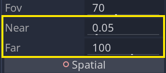

Any part of a model that’s closer than the *Near* distance gets clipped off. Any part of a model that’s further away than the *Far* distance also gets clipped off.

[figure not shown]

Godot can handle rendering lots of vertices, so increasing these distances will not drastically affect performance on most devices. You can read more about performance optimizations in the guide for VisibilityNotifier.

### My Camera doesn’t rotate the way I expect

If your `Camera` spins in strange directions, or spins a lot, you may be facing some issues:

- You assigned a degree value to `rotation` without using `deg2rad()` first.
- You’re using *Euler* angles and put your `Camera` in a state of gimbal lock.
- You have interpolations that make the angles wrap to zero.

#### Converting to Radians

If your camera is rotating way more than anticipated, it might be that you’re assigning a degree value of `90` to a property that uses radians.

Degrees and radians are two different ways of measuring angles. For a `Spatial` node in Godot, the code-only `rotation` property accepts radians, while the *Rotation Degrees* property accepts degrees.

You can convert between the two values using the `deg2rad()` and `rad2deg()` methods.

#### Interpolation issues

When interpolating between two angle values, you can use functions to cause an angle to wrap back to `0`. For example, `wrapf()` function.

If you want to use linear interpolation, the `lerp_angle()` function supports the wrapping and rotates the shortest distance to reach a target.

We generally recommend working with Godot’s `Transform`, `Basis`, and `Quat` to manipulate 3D objects as they make your code easier to maintain compared to using translation, rotation, and scale individually.

#### Gimbal lock

Gimbal lock occurs when objects rotate using *Euler* angles, causing the object’s local axes to rotate and align. An object that starts with three axes of rotation loses precision when two of these axes become parallel. This is an issue in all 3D software when using rotations around local axes.

In Godot, gimbal lock can happen on any `Spatial` node that uses `rotation` and `rotation_degrees` properties. The `rotate()`, `rotate_x()`, `rotate_y()`, and `rotate_z()` methods also can have this problem.

There are two solutions for gimbal lock and angles wrapping to zero, quaternions and transforms.

Godot has a `Quat` type as its implementation of quaternions. The `Quat` has an extra fourth axis to avoid gimbal lock. Many `Spatial` methods that rotate your 3D objects like `look_at()` uses `Quat` to avoid gimbal lock. You can read more about using quaternions in the [Godot Docs page on Quat.](https://docs.godotengine.org/en/stable/tutorials/3d/using_transforms.html#interpolating-with-quaternions)

Additionally, you can read more about gimbal lock on the [Godot Docs page on using transforms.](https://docs.godotengine.org/en/stable/tutorials/3d/using_transforms.html)

#### Transforms

All 3D nodes have a `Transform` consisting of an origin and a `Basis`. The origin is the node’s position relative to its parent, while the `Basis` represents its rotation and scale in three vectors: the node’s local axes.

We can get the rotation from a `Basis` object as a quaternion to work exclusively with rotations. Then, we can convert the value back to a basis to apply the rotation to our object.

In the following snippet, we take the `Basis` from two transforms and interpolate their rotation.

```
func interpolate_transform(from: Transform, to: Transform, weight: float) -> Transform:
    var quat_a: = from.basis.get_rotation_quat()
    var quat_b: = to.basis.get_rotation_quat()
    var origin_a: = from.origin
    var origin_b: = to.origin
    var final_transform: = Transform(quat_a.slerp(quat_b, weight), lerp(origin_a, origin_b, weight))
    return final_transform
```

## Your questions

### How can I find if an object is in front of the camera?

We often need to compare where the `Camera` is relative to other objects. For example, enemies won’t attack you in some action games if they are behind the `Camera`.

Imagine a chest with an area that controls when the player can interact with it. You may want to ensure that the player is facing the chest before opening it.

```
var can_see_object := not is_position_behind(object.global_position)
```

This method only works with global positions.

### How can I mark the position of a 3D object on the screen?

It’s common in triple-A games to have icons over essential objects in the world to help the player navigate and find critical objects.

You might want to mark these entities with crisp 2D icons rendered above everything else. This icon keeps them visible regardless of what’s happening in the game.

For this, you need to map the position of 3D models in the world to 2D screen coordinates. The camera node provides the `unproject_position()` method for this situation.

```
# The camera projects the position onto the screen even if the object is behind
# it so you need to check for that.
var is_object_in_front := not is_position_behind(global_position)
sprite.visible = is_object_in_front
if is_object_in_front:
    var screen_position := unproject_position(target.global_position)
    sprite.global_position = screen_position
```

### What are Cull Masks?

Culling is the process of hiding some geometry from rendering. Godot comes with rendering layers you can use to hide objects and lights from specific cameras.

You can assign any 3D mesh or light node to different rendering layers.

[figure not shown]

If you unset the corresponding bit on a `Camera` node’s *Cull Mask* property, the related geometry and lights don’t render when the `Camera`’s active.

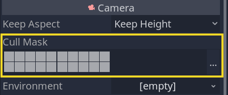

You can use that property to make objects invisible unless the player uses a special item or spell. It can also help with rendering performance as culled objects don’t render.